[← Volver a Día 3](https://valentinzarate.github.io/taller_mov/tema_3/tema3.html)

# SSF

# Step Selection Functions

En el Notebook anterior vimos la lógica general de las **Resource Selection Functions**, o RSF. La idea central era comparar lugares usados contra lugares disponibles. Para eso tomamos puntos observados de la trayectoria separados por un tiempo suficiente (para lograr independencia) y los comparamos contra puntos aleatorios generados dentro de una definición de disponibilidad, por ejemplo el MCP 100%.

Los RSF son super útiles pero no modelan la trayectoria, de hecho “eliminarla” es parte de sus supuestos. Si queremos entender en una escala más fina que incluya la autocorrelación real de los puntos entonces tenemos que modelar a nivel de paso.

Aca es donde entran los **Step Selection Functions**, o SSF, cambian la definición de disponibilidad. En vez de comparar puntos usados contra puntos disponibles en todo el paisaje, comparan cada **paso observado** contra un conjunto de **pasos alternativos** que el animal podría haber realizado desde el mismo punto de partida.

## De RSF a SSF

En una RSF, la unidad de análisis suele ser el punto:

**punto usado vs. punto disponible**

En una SSF, la unidad de análisis es el paso:

**paso observado vs. pasos disponibles**

Un paso está definido por dos posiciones consecutivas:

**Z<sub>t</sub> → Z<sub>t+1</sub>**

donde `Z` representa la posición del animal. Como venimos trabajando con números complejos, podemos escribir:

**Z<sub>t</sub> = X<sub>t</sub> + iY<sub>t</sub>**

Entonces, el desplazamiento entre dos posiciones consecutivas es:

**ΔZ<sub>t</sub> = Z<sub>t+1</sub> - Z<sub>t</sub>**

Ese desplazamiento tiene dos componentes importantes:

- **longitud del paso:** qué distancia se movió el animal;
- **ángulo de giro:** cuánto cambió su dirección respecto al paso anterior.

```r
library(sf)
library(terra)
library(dplyr)
library(ggplot2)
library(survival)
```

Vamos a empezar con una trayectoria simulada. La lógica será la misma que en los Notebooks anteriores: primero trabajamos con datos simulados para controlar mejor lo que está ocurriendo, y después podemos pasar a datos reales.

VAmos a agregar una capa de “pueblos” a la que teniamos antes, como para ver cómo podemos generar información a aprtir de dos covariables ambientales, una raster y otra vectorial

| town_id | X | Y | radius |
| --- | --- | --- | --- |
| pueblo_1 | 35.762241 | -67.93443 | 11.259528 |
| pueblo_2 | -78.806410 | -29.80630 | 6.714289 |
| pueblo_3 | 1.001656 | -74.37696 | 11.411297 |
| pueblo_4 | 4.955431 | -91.92725 | 11.718648 |

|  | town_id | X | Y | radius | geometry |
| --- | --- | --- | --- | --- | --- |
| 1 | pueblo_1 | 35.762241 | -67.93443 | 11.259528 |  |
| 2 | pueblo_2 | -78.806410 | -29.80630 | 6.714289 |  |
| 3 | pueblo_3 | 1.001656 | -74.37696 | 11.411297 |  |
| 4 | pueblo_4 | 4.955431 | -91.92725 | 11.718648 |  |

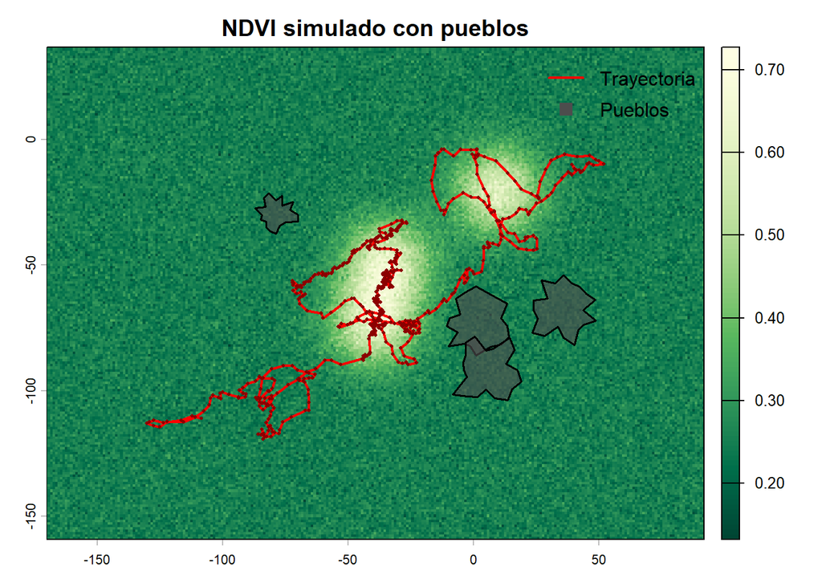

Los vectores parecen muy distintos a los raster, pero en realidad son muy intercambiables.. Creo que tanto en RSF como en SSF esta bueno trabajar con todo raster o todo vector, no es obligado pero es más facil. Ahora rasterizo los pueblos para tener una capa de distancia al pueblo más cercano.

```r
town_raster <- r
values(town_raster) <- NA
names(town_raster) <- "town"

# Rasterizamos pueblos: 1 dentro de pueblos, NA fuera
town_raster <- terra::rasterize(terra::vect(towns_sf),
                                town_raster,
                                field = 1,
                                background = NA)

# Distancia desde cada celda al pueblo más cercano
dist_town <- terra::distance(town_raster)

names(dist_town) <- "dist_town"
```

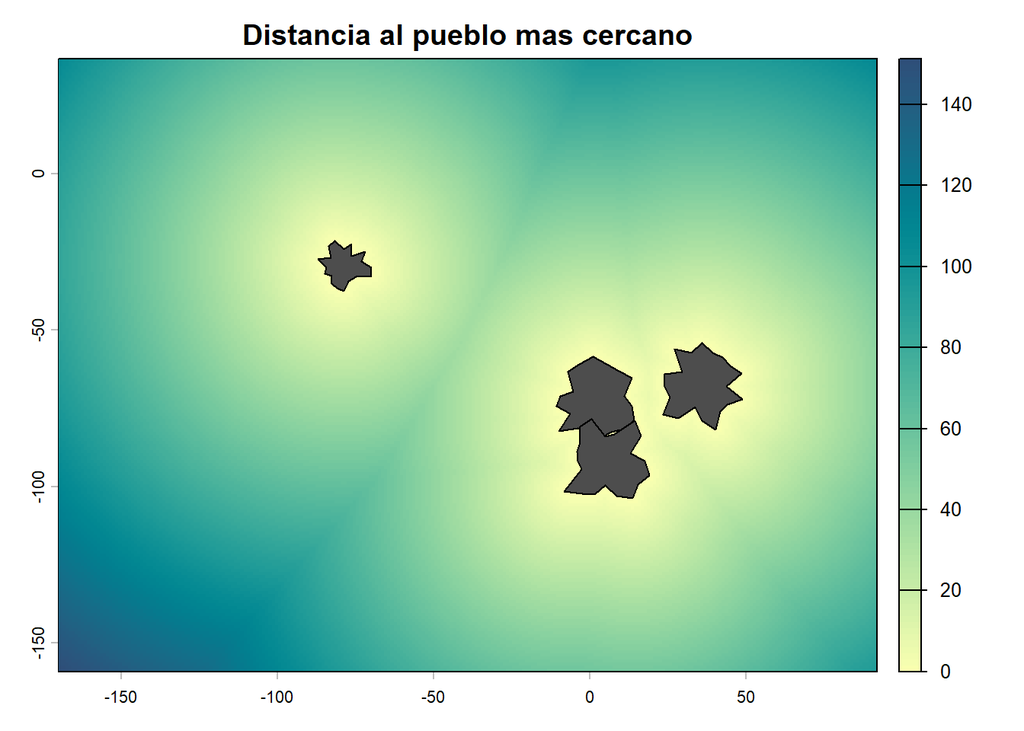

```r
plot(dist_town,
     main = "Distancia al pueblo mas cercano",
     col = hcl.colors(100, "BluYl", rev = TRUE))

plot(st_geometry(towns_sf),
     add = TRUE,
     col = "grey30",
     border = "black")
```

#### Raster Stack

Algo que ya vimos es que podemos apilar todos los raster (siempre y cuando compartan CRS y resolucion) en un stack.

```r
env_stack <- c(r, dist_town)
names(env_stack)
```

```
## [1] "NDVI"      "dist_town"
```

## Pasos posibles

VAmos a hacer un zoom sobre la trayectoria para ir entendiendo cómo se va preparando la data.frame para ajustar el SSF

```r
start_i <- 120
n_zoom <- 15

df_zoom <- df[start_i:(start_i + n_zoom - 1), ]

df_zoom$local_id <- 1:nrow(df_zoom)
```

Para entender cómo se construye una Step Selection Function, primero vamos a mirar un tramo pequeño de la trayectoria. Usaremos sólo 15 posiciones consecutivas. Esto nos permite ver con claridad cómo se forman los pasos observados y cómo se generan pasos alternativos.

Cada posición puede escribirse como un número complejo:

**Z<sub>t</sub> = X<sub>t</sub> + iY<sub>t</sub>**

Esta representación es útil porque un desplazamiento entre dos posiciones consecutivas se puede calcular simplemente como una resta entre números complejos.

```r
df_zoom$Z <- df_zoom$X + 1i * df_zoom$Y

df_zoom[, c("local_id", "X", "Y", "Z")]
```

|  | local_id | X | Y | Z |
| --- | --- | --- | --- | --- |
| 120 | 1 | -3.111719 | -57.05565 | -3.111719-57.05565i |
| 121 | 2 | -2.155494 | -54.90949 | -2.155494-54.90949i |
| 122 | 3 | -2.557814 | -55.16914 | -2.557814-55.16914i |
| 123 | 4 | -2.759250 | -51.81556 | -2.759250-51.81556i |
| 124 | 5 | -5.507107 | -55.81711 | -5.507107-55.81711i |
| 125 | 6 | -7.211743 | -59.44655 | -7.211743-59.44655i |
| 126 | 7 | -7.593687 | -60.79998 | -7.593687-60.79998i |
| 127 | 8 | -8.670596 | -61.54149 | -8.670596-61.54149i |
| 128 | 9 | -10.713040 | -64.60389 | -10.713040-64.60389i |
| 129 | 10 | -11.684341 | -63.44689 | -11.684341-63.44689i |

[output cut: 5 more lines]

La columna `Z` contiene la posición espacial escrita como un número complejo. La parte real de `Z` es la coordenada `X`, y la parte imaginaria es la coordenada `Y`.

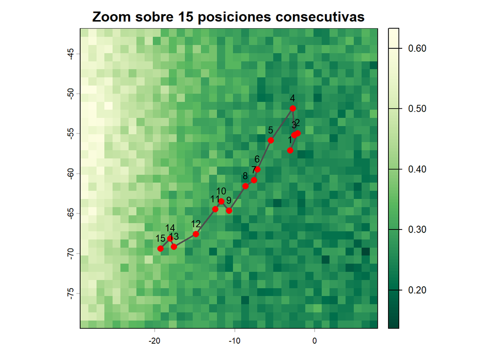

```r
plot(r,
     main = "Zoom sobre 15 posiciones consecutivas",
     col = hcl.colors(100, "YlGn"),
     xlim = range(df_zoom$X) + c(-10, 10),
     ylim = range(df_zoom$Y) + c(-10, 10))

lines(df_zoom$X,
      df_zoom$Y,
      col = "grey30",
      lwd = 2)

points(df_zoom$X,
       df_zoom$Y,
       pch = 16,
       cex = 1.2,
       col = "red")

text(df_zoom$X,
     df_zoom$Y,
     labels = df_zoom$local_id,
     pos = 3,
     cex = 0.8)
```

En este gráfico vemos 15 posiciones consecutivas. Los números indican el orden temporal de las posiciones. Una SSF no trabaja directamente con puntos aislados, sino con los pasos que conectan posiciones consecutivas.

Cada paso observado conecta una posición inicial con una posición final:

**Z<sub>t</sub> → Z<sub>t+1</sub>**

El desplazamiento entre esas dos posiciones se calcula como:

**ΔZ<sub>t</sub> = Z<sub>t+1</sub> - Z<sub>t</sub>**

Este desplazamiento contiene toda la información geométrica del paso. A partir de `ΔZ` podemos calcular la longitud del paso y su dirección.

```r
steps_zoom <- df_zoom |>
  arrange(t) |>
  mutate(
    Z_start = Z,
    Z_end = lead(Z),
    X_start = X,
    Y_start = Y,
    X_end = lead(X),
    Y_end = lead(Y),
    t_start = t,
    t_end = lead(t)
  ) |>
  filter(!is.na(Z_end)) |>
  mutate(
    dZ = Z_end - Z_start,
    step_length = Mod(dZ),
    direction = Arg(dZ),
    step_id = row_number()
  )

steps_zoom[, c("step_id", "Z_start", "Z_end", "dZ", "step_length", "direction")]
```

| step_id | Z_start | Z_end | dZ | step_length | direction |
| --- | --- | --- | --- | --- | --- |
| 1 | -3.111719-57.05565i | -2.155494-54.90949i | 0.9562244+2.1461620i | 2.3495482 | 1.151648 |
| 2 | -2.155494-54.90949i | -2.557814-55.16914i | -0.4023201-0.2596554i | 0.4788344 | -2.568462 |
| 3 | -2.557814-55.16914i | -2.759250-51.81556i | -0.2014357+3.3535833i | 3.3596276 | 1.630790 |
| 4 | -2.759250-51.81556i | -5.507107-55.81711i | -2.7478573-4.0015501i | 4.8541861 | -2.172539 |
| 5 | -5.507107-55.81711i | -7.211743-59.44655i | -1.7046355-3.6294457i | 4.0098202 | -2.009885 |
| 6 | -7.211743-59.44655i | -7.593687-60.79998i | -0.3819442-1.3534276i | 1.4062886 | -1.845849 |
| 7 | -7.593687-60.79998i | -8.670596-61.54149i | -1.0769089-0.7415121i | 1.3075064 | -2.538589 |
| 8 | -8.670596-61.54149i | -10.713040-64.60389i | -2.0424437-3.0623945i | 3.6810102 | -2.158990 |
| 9 | -10.713040-64.60389i | -11.684341-63.44689i | -0.9713017+1.1569969i | 1.5106518 | 2.269164 |
| 10 | -11.684341-63.44689i | -12.451479-64.42389i | -0.7671372-0.9769994i | 1.2421865 | -2.236446 |

[output cut: 4 more lines]

La longitud del paso es la distancia entre la posición inicial y la posición final. En términos de números complejos:

**l<sub>t</sub> = |ΔZ<sub>t</sub>| = |Z<sub>t+1</sub> - Z<sub>t</sub>|**

En R, la función `Mod()` calcula el módulo de un número complejo. Por eso usamos:

**step_length = Mod(dZ)**

La dirección del paso es el ángulo del desplazamiento. En números complejos se calcula con el argumento:

**θ<sub>t</sub> = Arg(ΔZ<sub>t</sub>)**

En R, la función `Arg()` devuelve ese ángulo en radianes, entre `-π` y `π`.

```r
steps_zoom$direction_deg <- steps_zoom$direction * 180 / pi
steps_zoom[, c("step_id", "direction", "direction_deg")]
```

| step_id | direction | direction_deg |
| --- | --- | --- |
| 1 | 1.151648 | 65.98460 |
| 2 | -2.568462 | -147.16200 |
| 3 | 1.630790 | 93.43739 |
| 4 | -2.172539 | -124.47732 |
| 5 | -2.009885 | -115.15795 |
| 6 | -1.845849 | -105.75934 |
| 7 | -2.538589 | -145.45041 |
| 8 | -2.158990 | -123.70104 |
| 9 | 2.269164 | 130.01354 |
| 10 | -2.236446 | -128.13890 |

[output cut: 4 more lines]

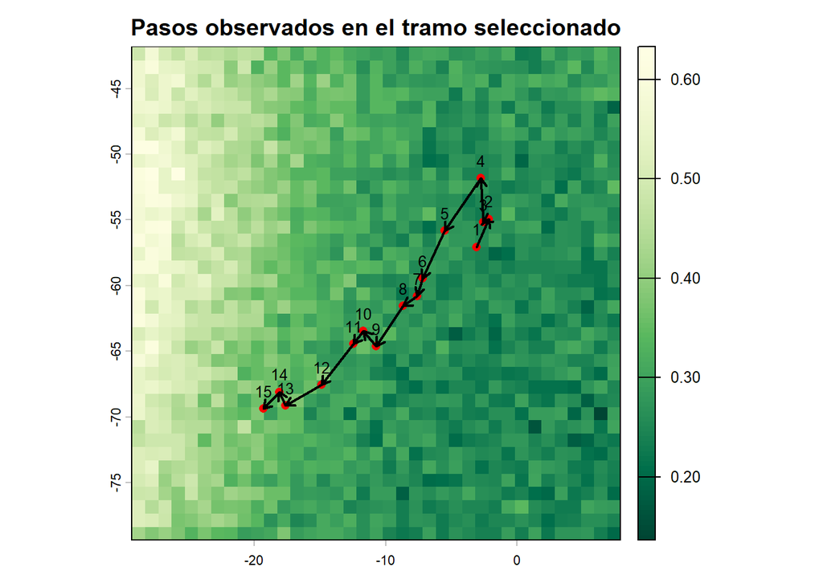

```r
plot(r,
     main = "Pasos observados en el tramo seleccionado",
     col = hcl.colors(100, "YlGn"),
     xlim = range(df_zoom$X) + c(-10, 10),
     ylim = range(df_zoom$Y) + c(-10, 10))

points(df_zoom$X,
       df_zoom$Y,
       pch = 16,
       cex = 1,
       col = "red")

arrows(steps_zoom$X_start,
       steps_zoom$Y_start,
       steps_zoom$X_end,
       steps_zoom$Y_end,
       length = 0.08,
       lwd = 2,
       col = "black")

text(df_zoom$X,
     df_zoom$Y,
     labels = df_zoom$local_id,
     pos = 3,
     cex = 0.8)
```

### Distribuciones de movimiento

Para generar pasos posibles necesitamos decidir qué longitudes y qué direcciones pueden tener. Lo más simple es usar las distribuciones observadas en la trayectoria completa. Estamos incluyendo lo que sabemos del animal..

```r
steps_all <- df |>
  arrange(t) |>
  mutate(
    Z_start = Z,
    Z_end = lead(Z),
    X_start = X,
    Y_start = Y,
    X_end = lead(X),
    Y_end = lead(Y),
    t_start = t,
    t_end = lead(t)
  ) |>
  filter(!is.na(Z_end)) |>
  mutate(
    dZ = Z_end - Z_start,
    step_length = Mod(dZ),
    direction = Arg(dZ),
    step_id = row_number()
  )
```

### Distribución de longitudes de paso

Para generar pasos alternativos realistas, podemos usar la distribución empírica de longitudes de paso observadas en la trayectoria completa. Esto significa que los pasos alternativos tendrán distancias parecidas a las que el animal efectivamente recorrió.

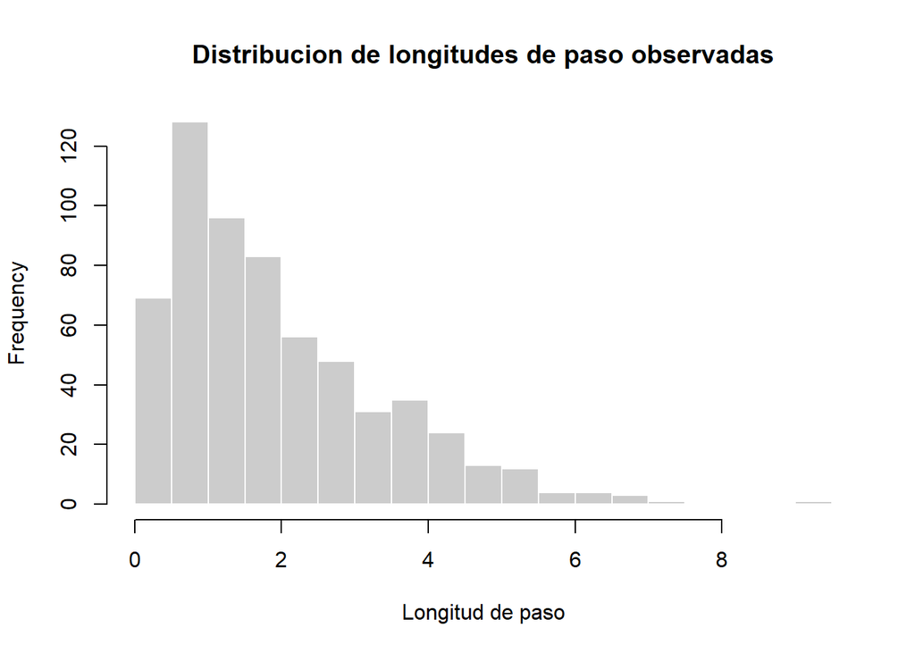

```r
hist(steps_all$step_length,
     breaks = 30,
     col = "grey80",
     border = "white",
     main = "Distribucion de longitudes de paso observadas",
     xlab = "Longitud de paso")
```

### Distribución de angulos de giro

El ángulo de giro mide cuánto cambia la dirección entre un paso y el siguiente.

**α<sub>t</sub> = θ<sub>t</sub> - θ<sub>t-1</sub>**

Si el ángulo de giro está cerca de 0, el animal continúa aproximadamente en la misma dirección. Si el ángulo está cerca de π o -π, el animal gira casi en sentido contrario.

Como los ángulos son circulares, usamos una corrección para mantenerlos dentro del intervalo `-π` a `π`:

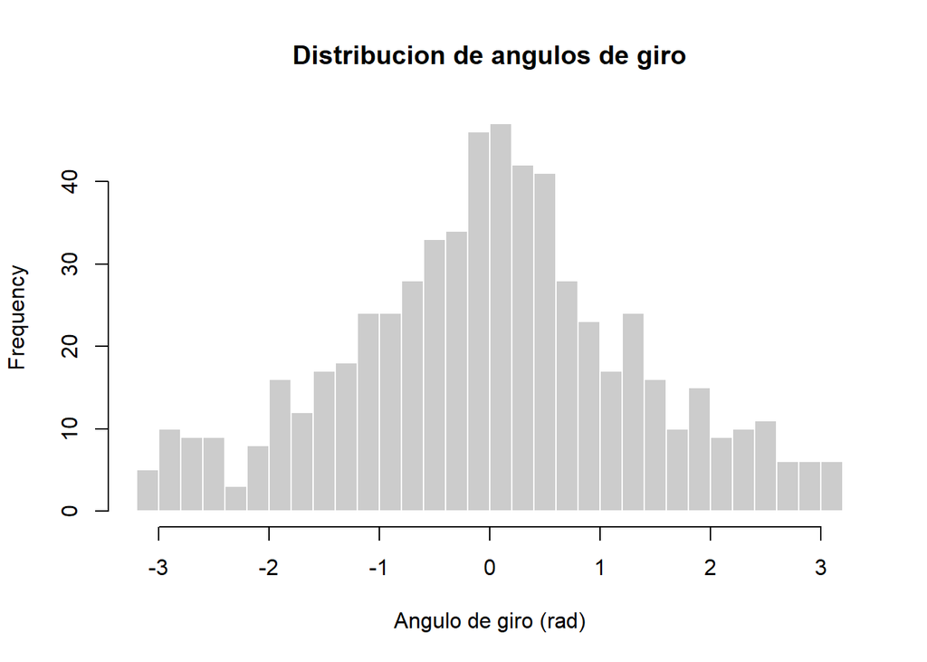

```r
steps_all <- steps_all |>
  mutate(
    previous_direction = lag(direction),
    turn_angle = direction - previous_direction
  )

steps_all$turn_angle <- atan2(sin(steps_all$turn_angle),
                              cos(steps_all$turn_angle))

steps_all <- steps_all |>
  filter(!is.na(turn_angle))


hist(steps_all$turn_angle,
     breaks = 30,
     col = "grey80",
     border = "white",
     main = "Distribucion de angulos de giro",
     xlab = "Angulo de giro (rad)")
```

### PAso focal

Para entender la información base que usan los SSF nos concentremos en un solo paso.

```r
focal_step_id <- 6

focal_step <- steps_zoom |>
  filter(step_id == focal_step_id)

focal_step
```

| id | X | Y | Z | t | seg_id | is_cluster_original | local_id | Z_start | Z_end | X_start | Y_start | X_end | Y_end | t_start | t_end | dZ | step_length | direction | step_id | direction_deg |
| --- | --- | --- | --- | --- | --- | --- | --- | --- | --- | --- | --- | --- | --- | --- | --- | --- | --- | --- | --- | --- |
| 125 | -7.211743 | -59.44655 | -7.211743-59.44655i | 2024-01-06 04:00:00 | 2 | FALSE | 6 | -7.211743-59.44655i | -7.593687-60.79998i | -7.211743 | -59.44655 | -7.593687 | -60.79998 | 2024-01-06 04:00:00 | 2024-01-06 05:00:00 | -0.3819442-1.353428i | 1.406289 | -1.845849 | 6 | -105.7593 |

Esto dejo de ser un punto, sino que tiene la información de dos puntos juntos.. acá hay cosas importantes ecologicamente. En estas columnas tenemos el punto del partida del animal, el punto de llegada y también el tracyecto entre ambos. Cada elemento puede responder a cosas distintas.

```r
set.seed(10)

n_available <- 20

start_z <- focal_step$Z_start

rand_lengths <- sample(steps_all$step_length,
                       size = n_available,
                       replace = TRUE)

rand_angles <- runif(n_available,
                     min = -pi,
                     max = pi)

end_z_available <- start_z + rand_lengths * exp(1i * rand_angles)

avail_simple <- data.frame(
  used = 0,
  X_start = Re(start_z),
  Y_start = Im(start_z),
  X_end = Re(end_z_available),
  Y_end = Im(end_z_available),
  step_length = rand_lengths,
  angle = rand_angles)

obs_simple <- data.frame(
  used = 1,
  X_start = focal_step$X_start,
  Y_start = focal_step$Y_start,
  X_end = focal_step$X_end,
  Y_end = focal_step$Y_end,
  step_length = focal_step$step_length,
  angle = focal_step$direction)

steps_focal_simple <- rbind(obs_simple, avail_simple)
```

La fórmula usada para construir cada punto final alternativo es:

**Z<sub>end</sub> = Z<sub>start</sub> + l e<sup>iθ*</sup>**

donde `l` es una longitud de paso muestreada desde la distribución observada, y `θ` es una dirección aleatoria.

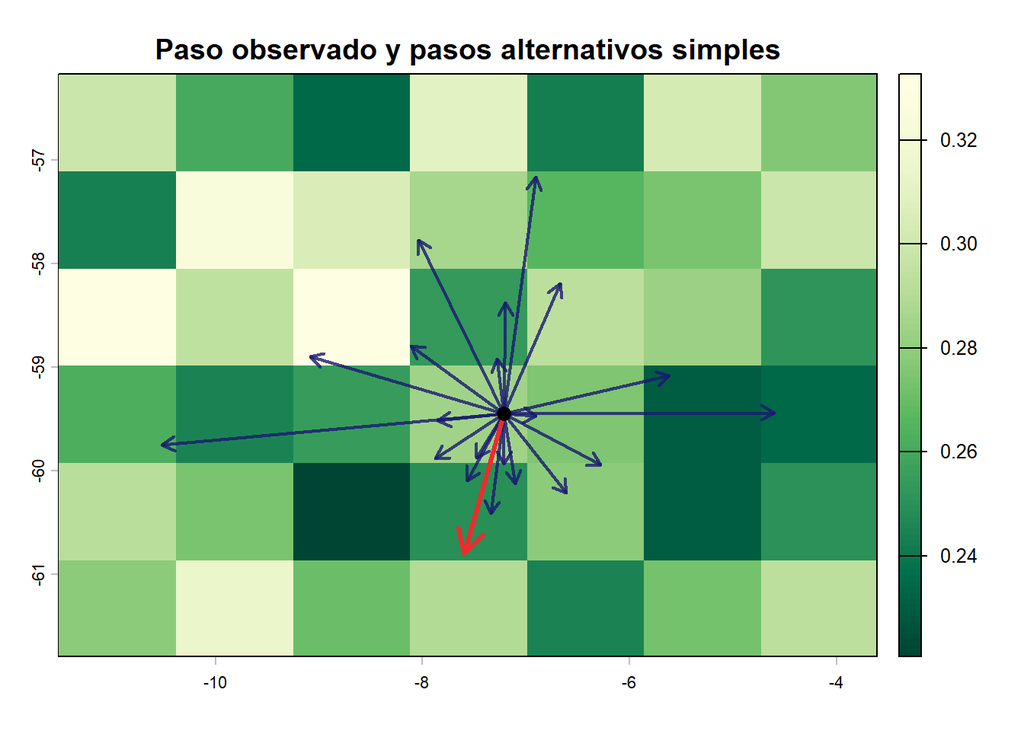

```r
plot(r,
     main = "Paso observado y pasos alternativos simples",
     col = hcl.colors(100, "YlGn"),
     xlim = range(c(steps_focal_simple$X_start, steps_focal_simple$X_end)) + c(-1, 1),
     ylim = range(c(steps_focal_simple$Y_start, steps_focal_simple$Y_end)) + c(-1, 1))

arrows(avail_simple$X_start,
       avail_simple$Y_start,
       avail_simple$X_end,
       avail_simple$Y_end,
       length = 0.1, lwd = 2,
       col = adjustcolor("midnightblue", alpha.f = 0.8))

arrows(obs_simple$X_start,
       obs_simple$Y_start,
       obs_simple$X_end,
       obs_simple$Y_end,
       length = 0.18,
       lwd = 3,
       col = "firebrick2")

points(obs_simple$X_start,
       obs_simple$Y_start,
       pch = 16,
       cex = 1.3,
       col = "black")
```

```r
focal_step_id <- 6

focal_step <- steps_zoom |>
  filter(step_id == focal_step_id)

previous_step <- steps_zoom |>
  filter(step_id == focal_step_id - 1)

previous_direction <- previous_step$direction

set.seed(20)

n_available <- 20

# 1. Muestreamos longitudes de paso
rand_lengths <- sample(steps_all$step_length,
                       size = n_available,
                       replace = TRUE)

# 2. Muestreamos ángulos de giro
rand_turns <- sample(steps_all$turn_angle,
                     size = n_available,
                     replace = TRUE)

# 3. Construimos nuevas direcciones
new_directions <- previous_direction + rand_turns

# 4. Reajustamos los ángulos al intervalo -pi, pi
new_directions <- atan2(sin(new_directions),
                        cos(new_directions))

# 5. Calculamos puntos finales alternativos
start_z <- focal_step$Z_start

end_z_available <- start_z + rand_lengths * exp(1i * new_directions)

avail_steps <- data.frame(
  used = 0,
  X_start = Re(start_z),
  Y_start = Im(start_z),
  X_end = Re(end_z_available),
  Y_end = Im(end_z_available),
  step_length = rand_lengths,
  turn_angle = rand_turns,
  direction = new_directions
)

obs_step <- data.frame(
  used = 1,
  X_start = focal_step$X_start,
  Y_start = focal_step$Y_start,
  X_end = focal_step$X_end,
  Y_end = focal_step$Y_end,
  step_length = focal_step$step_length,
  turn_angle = atan2(
    sin(focal_step$direction - previous_direction),
    cos(focal_step$direction - previous_direction)
  ),
  direction = focal_step$direction
)

steps_focal <- rbind(obs_step, avail_steps)
```

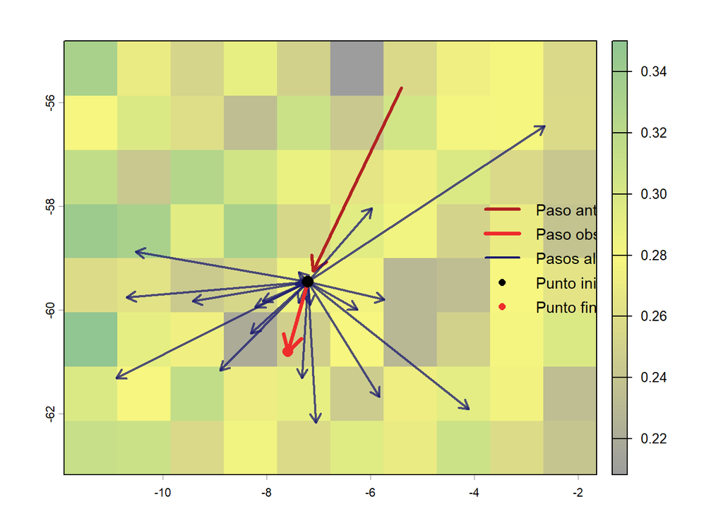

```r
# Guardamos parámetros gráficos originales
op <- par(no.readonly = TRUE)

# Agrandamos margen derecho
par(mar = c(5, 4, 4, 8), xpd = TRUE)

r_bg_cols <- colorRampPalette(c("grey23", "yellow2", "forestgreen"))(100)

plot(r,
     col = r_bg_cols,
     alpha = 0.5,
     xlim = range(c(steps_focal$X_start, steps_focal$X_end,
                    previous_step$X_start, previous_step$X_end)) + c(-1, 1),
     ylim = range(c(steps_focal$Y_start, steps_focal$Y_end,
                    previous_step$Y_start, previous_step$Y_end)) + c(-1, 1))

# Paso anterior
arrows(previous_step$X_start + 0.1,
       previous_step$Y_start + 0.1,
       previous_step$X_end + 0.1,
       previous_step$Y_end + 0.2,
       length = 0.16,
       lwd = 3,
       col = "firebrick")

# Pasos alternativos
arrows(steps_focal$X_start[steps_focal$used == 0],
       steps_focal$Y_start[steps_focal$used == 0],
       steps_focal$X_end[steps_focal$used == 0],
       steps_focal$Y_end[steps_focal$used == 0],
       length = 0.1,
       lwd = 2,
       col = adjustcolor("midnightblue", alpha.f = 0.75))

# Paso observado
arrows(steps_focal$X_start[steps_focal$used == 1],
       steps_focal$Y_start[steps_focal$used == 1],
       steps_focal$X_end[steps_focal$used == 1],
       steps_focal$Y_end[steps_focal$used == 1],
       length = 0.18,
       lwd = 3.5,
       col = "firebrick2")

# Punto de inicio focal
points(steps_focal$X_start[steps_focal$used == 1],
       steps_focal$Y_start[steps_focal$used == 1],
       pch = 16,
       cex = 1.5,
       col = "black")

# Punto final observado
points(steps_focal$X_end[steps_focal$used == 1],
       steps_focal$Y_end[steps_focal$used == 1],
       pch = 16,
       cex = 1.4,
       col = "firebrick2")

# Leyenda fuera del plot, a la derecha
legend("right",
       inset = c(-0.13, 0),
       legend = c("Paso anterior",
                  "Paso observado",
                  "Pasos alternativos",
                  "Punto inicial",
                  "Punto final observado"),
       lty = c(1, 1, 1, NA, NA),
       pch = c(NA, NA, NA, 16, 16),
       lwd = c(3, 3.5, 2, NA, NA),
       col = c("firebrick",
               "firebrick2",
               "midnightblue",
               "black",
               "firebrick2"),
       bty = "n",
       cex = 0.9)
```

```r
# Restauramos parámetros gráficos originales
par(op)
```

## SSF - `amt`

Ahora vamos a ajustar una SSF usando el paquete `amt`. La lógica será la misma que venimos trabajando manualmente, pero usando funciones diseñadas específicamente para datos de movimiento.

El flujo general será:

- convertir la trayectoria en un objeto `track`;
- construir pasos observados;
- generar pasos alternativos para cada paso observado;
- extraer covariables ambientales en el punto final de cada paso;
- ajustar una regresión logística condicional con `clogit`.

```r
library(amt)
library(sf)
library(terra)
library(dplyr)
library(ggplot2)
library(survival)
```

```r
df_amt <- df |>
  arrange(t) |>
  transmute(
    x = X,
    y = Y,
    t = t
  )

trk <- make_track(df_amt,
                  .x = x,
                  .y = y,
                  .t = t,
                  crs = terra::crs(r))
```

La función `make_track()` convierte nuestra tabla en un objeto de trayectoria. Indicamos qué columnas representan la coordenada X, la coordenada Y y el tiempo. También asignamos el mismo sistema de coordenadas que tiene el raster ambiental.

Antes de construir pasos conviene revisar el intervalo temporal entre fixes. Las SSF comparan movimientos entre posiciones consecutivas, por lo que es importante que el intervalo de muestreo sea relativamente regular.

```r
summarize_sampling_rate(trk)
```

| min | q1 | median | mean | q3 | max | sd | n | unit |
| --- | --- | --- | --- | --- | --- | --- | --- | --- |
| 1 | 1 | 1 | 1 | 1 | 1 | 0 | 608 | hour |

### Pasos Observados

La función `steps_by_burst()` transforma la trayectoria en pasos. Cada fila representa un desplazamiento entre dos posiciones consecutivas. El objeto resultante incluye, entre otras cosas, el punto inicial, el punto final, la longitud del paso y el ángulo de giro.

Para este ejemplo, como tenemos una sola trayectoria continua, no necesitamos bursts todavía. Para otros casos no hace falta ese mutate

```r
trk <- trk |>
  mutate(burst_ = 1L)

steps_obs <- steps_by_burst(trk)
```

```r
names(steps_obs)
```

```
##  [1] "burst_"      "x1_"         "x2_"         "y1_"         "y2_"
##  [6] "sl_"         "direction_p" "ta_"         "t1_"         "t2_"
## [11] "dt_"
```

Antes de construir los pasos con `amt`, armamos una versión limpia de la trayectoria usando solamente las coordenadas y el tiempo. Además, como en este ejemplo tenemos una sola trayectoria continua, asignamos todos los puntos al mismo `burst`. Un burst representa un tramo continuo de movimiento con intervalos de muestreo comparables.

### Pasos alternativos

Ya transformamos la trayectoria en pasos observados. Cada fila de `steps_obs` representa un movimiento entre dos posiciones consecutivas. Ahora vamos a generar pasos alternativos para cada paso observado.

Estos pasos alternativos empiezan en el mismo punto que el paso observado, pero terminan en otros lugares posibles. La función `random_steps()` genera esos pasos usando la distribución observada de longitudes de paso y ángulos de giro.

```r
set.seed(123)

ssf_steps <- steps_obs |>
  random_steps(n = 20)

head(ssf_steps)
```

|  | burst_ | x1_ | x2_ | y1_ | y2_ | sl_ | ta_ | t1_ | t2_ | dt_ | case_ | step_id_ |
| --- | --- | --- | --- | --- | --- | --- | --- | --- | --- | --- | --- | --- |
| 1 | 1 | 1.504632 | 1.4481275 | -10.26478 | -13.90353 | 3.6391887 | -0.45274216 | 2024-01-01 01:00:00 | 2024-01-01 02:00:00 | 1 hours | TRUE | 3 |
| 2 | 1 | 1.504632 | 2.2612122 | -10.26478 | -11.77508 | 1.6892128 | 0.02718822 | 2024-01-01 01:00:00 | 2024-01-01 02:00:00 | 1 hours | FALSE | 3 |
| 3 | 1 | 1.504632 | 2.3206520 | -10.26478 | -10.61235 | 0.8869589 | 0.73091617 | 2024-01-01 01:00:00 | 2024-01-01 02:00:00 | 1 hours | FALSE | 3 |
| 4 | 1 | 1.504632 | 1.9846061 | -10.26478 | -11.48279 | 1.3091757 | -0.06183818 | 2024-01-01 01:00:00 | 2024-01-01 02:00:00 | 1 hours | FALSE | 3 |
| 5 | 1 | 1.504632 | 1.3296962 | -10.26478 | -11.50603 | 1.2535234 | -0.57722722 | 2024-01-01 01:00:00 | 2024-01-01 02:00:00 | 1 hours | FALSE | 3 |
| 6 | 1 | 1.504632 | -0.1420164 | -10.26478 | -11.32875 | 1.9604843 | -1.43434929 | 2024-01-01 01:00:00 | 2024-01-01 02:00:00 | 1 hours | FALSE | 3 |

```r
table(ssf_steps$case_)
```

```
##
## FALSE  TRUE
## 12140   607
```

La columna `case_` identifica si el paso fue observado o alternativo. Cuando `case_ = TRUE`, el paso corresponde al movimiento realmente observado. Cuando `case_ = FALSE`, el paso es una alternativa disponible.

La columna `step_id_` identifica el conjunto de comparación: un paso observado y sus pasos alternativos. En una SSF, cada paso observado se compara únicamente contra las alternativas que pertenecen a su mismo `step_id_`.

```r
names(ssf_steps)
```

```
##  [1] "burst_"   "x1_"      "x2_"      "y1_"      "y2_"      "sl_"
##  [7] "ta_"      "t1_"      "t2_"      "dt_"      "case_"    "step_id_"
```

Algunas columnas importantes son:

- `x1_`, `y1_`: coordenadas iniciales del paso;
- `x2_`, `y2_`: coordenadas finales del paso;
- `sl_`: longitud del paso;
- `ta_`: ángulo de giro;
- `case_`: indica si el paso fue observado o alternativo;
- `step_id_`: identifica el estrato de comparación.

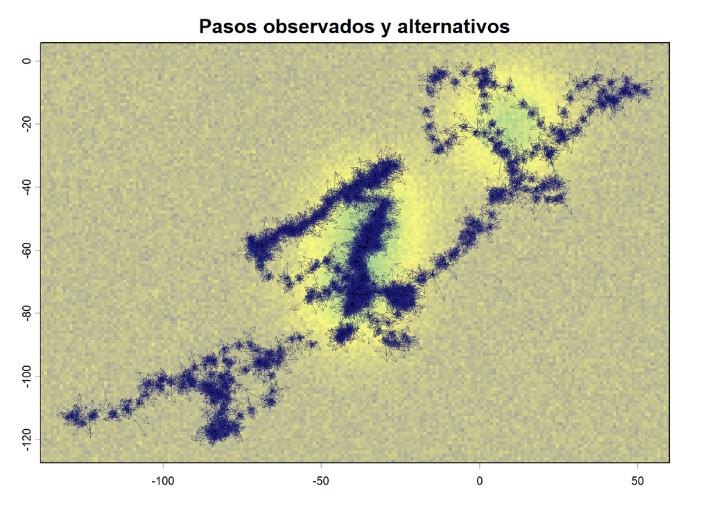

```r
set.seed(99)

ids_plot <- sample(unique(ssf_steps$step_id_), 600)

ssf_plot <- ssf_steps |>
  filter(step_id_ %in% ids_plot)

r_bg_cols <- colorRampPalette(c("grey23", "yellow2", "forestgreen"))(100)

plot(r,
     col = r_bg_cols,
     alpha = 0.5,
     legend = FALSE,
     main = "Pasos observados y alternativos",
     xlim = range(c(ssf_plot$x1_, ssf_plot$x2_), na.rm = TRUE) + c(-5, 5),
     ylim = range(c(ssf_plot$y1_, ssf_plot$y2_), na.rm = TRUE) + c(-5, 5))

arrows(ssf_plot$x1_[!ssf_plot$case_],
       ssf_plot$y1_[!ssf_plot$case_],
       ssf_plot$x2_[!ssf_plot$case_],
       ssf_plot$y2_[!ssf_plot$case_],
       length = 0.06,
       lwd = 0.2,
       col = adjustcolor("midnightblue", alpha.f = 0.45))


points(ssf_plot$x1_[ssf_plot$case_],
       ssf_plot$y1_[ssf_plot$case_],
       pch = 16,
       cex = 0.1,
       col = "black")
```

### Covariables

En una SSF, normalmente evaluamos las características ambientales del punto final de cada paso. En este ejemplo extraemos dos variables: `NDVI` y distancia al pueblo más cercano.

La pregunta ecológica será: dado el punto de partida y los movimientos alternativos disponibles, ¿el animal tiende a elegir pasos que terminan en sitios con mayor NDVI o más alejados de los pueblos?

```r
ssf_cov <- ssf_steps |>
  extract_covariates(env_stack)
```

### Preparo Datos

Escalamos las covariables para facilitar la interpretación. Después de escalar, un aumento de una unidad equivale a un aumento de una desviación estándar en la variable original. Esto permite comparar mejor la magnitud de los coeficientes.

```r
ssf_cov <- ssf_cov |>
  filter(!is.na(NDVI),
         !is.na(dist_town)) |>
  mutate(
    NDVI_s = as.numeric(scale(NDVI)),
    dist_town_s = as.numeric(scale(dist_town))
  )

summary(ssf_cov[, c("NDVI", "dist_town", "NDVI_s", "dist_town_s")])
```

```
##       NDVI          dist_town         NDVI_s         dist_town_s
##  Min.   :0.1623   Min.   : 0.00   Min.   :-1.7157   Min.   :-2.0168
##  1st Qu.:0.2807   1st Qu.:26.00   1st Qu.:-0.9542   1st Qu.:-0.5699
##  Median :0.4110   Median :31.05   Median :-0.1171   Median :-0.2889
##  Mean   :0.4292   Mean   :36.24   Mean   : 0.0000   Mean   : 0.0000
##  3rd Qu.:0.5805   3rd Qu.:42.76   3rd Qu.: 0.9726   3rd Qu.: 0.3626
##  Max.   :0.7270   Max.   :95.38   Max.   : 1.9146   Max.   : 3.2914
```

### Ajustamos SSF

```r
m_ssf <- fit_clogit(ssf_cov,
                    case_ ~ NDVI_s + dist_town_s + strata(step_id_))

summary(m_ssf)
```

```
## Call:
## coxph(formula = Surv(rep(1, 12747L), case_) ~ NDVI_s + dist_town_s +
##     strata(step_id_), data = data, method = "exact")
##
##   n= 12747, number of events= 607
##
##                coef exp(coef) se(coef)     z Pr(>|z|)
## NDVI_s      0.29748   1.34646  0.18325 1.623    0.105
## dist_town_s 0.01155   1.01161  0.47393 0.024    0.981
##
##             exp(coef) exp(-coef) lower .95 upper .95
## NDVI_s          1.346     0.7427    0.9402     1.928
## dist_town_s     1.012     0.9885    0.3996     2.561
##
## Concordance= 0.517  (se = 0.013 )
## Likelihood ratio test= 2.69  on 2 df,   p=0.3
## Wald test            = 2.69  on 2 df,   p=0.3
## Score (logrank) test = 2.69  on 2 df,   p=0.3
```

```r
coef(m_ssf)
```

```
##      NDVI_s dist_town_s
##  0.29747917  0.01154605
```

```r
exp(coef(m_ssf))
```

```
##      NDVI_s dist_town_s
##    1.346460    1.011613
```

Por cada aumento de una desviación estándar en NDVI, los odds relativos de que un paso sea elegido aumentan aproximadamente **1.35 veces**, es decir, un 35% aproximadamente.

Un aumento de una desviación estándar en la distancia al pueblo más cercano cambia los odds relativos de selección por un factor de aproximadamente **1.01**, es decir, casi nada.

## Integrated Step Selection Function

Ahora hacemos la versión más completa. random_steps() ya usa longitudes y ángulos para generar alternativas, pero si además incluimos sl_, log(sl_) y cos(ta_) en el modelo, estamos ajustando una integrated Step Selection Function.

En este segundo modelo agregamos términos de movimiento. La longitud del paso, su logaritmo y el coseno del ángulo de giro permiten modelar el proceso de movimiento además de la selección ambiental.

El término `cos_ta` mide persistencia direccional. Cuando el ángulo de giro está cerca de cero, `cos(ta_)` está cerca de 1. Eso representa pasos que continúan en una dirección similar a la dirección previa. Cuando el giro es cercano a π o -π, `cos(ta_)` está cerca de -1, lo que representa pasos que vuelven hacia atrás.

Este tipo de modelo integra dos procesos: selección de hábitat y movimiento. Por eso se conoce como iSSF.

```r
ssf_cov <- ssf_cov |>
  mutate(
    sl_safe = ifelse(sl_ <= 0, NA, sl_),
    log_sl = log(sl_safe),
    cos_ta = cos(ta_)
  ) |>
  filter(!is.na(log_sl),
         !is.na(cos_ta))
```

```r
m_issf <- survival::clogit(case_ ~ NDVI_s + dist_town_s +
                             sl_safe + log_sl + cos_ta +
                             strata(step_id_),
                           data = ssf_cov)
```

```r
AIC(m_ssf, m_issf)
```

|  | df | AIC |
| --- | --- | --- |
| object$model | 2 | 3697.358 |
| ..1 | 5 | 3703.150 |

La SSF simple evalúa selección ambiental condicionada a los pasos alternativos generados. La iSSF agrega términos de movimiento al modelo, lo que permite estimar simultáneamente la selección por covariables ambientales y parámetros asociados al movimiento.

Para este taller, lo más importante no es elegir “el mejor” modelo, sino entender cómo cambia la interpretación: una SSF compara pasos observados contra pasos disponibles; una iSSF además modela explícitamente componentes del movimiento como distancia recorrida y persistencia direccional.

```r
sum_m <- summary(m_ssf)

coef_tab <- as.data.frame(sum_m$coefficients)
coef_tab$term <- rownames(coef_tab)

coef_tab
```

|  | coef | exp(coef) | se(coef) | z | Pr(>\|z\|) | term |
| --- | --- | --- | --- | --- | --- | --- |
| NDVI_s | 0.29747917 | 1.346460 | 0.1832453 | 1.6233928 | 0.1045055 | NDVI_s |
| dist_town_s | 0.01154605 | 1.011613 | 0.4739347 | 0.0243621 | 0.9805638 | dist_town_s |

```r
ssf_coef <- coef_tab |>
  mutate(
    estimate = `exp(coef)`,
    conf.low = exp(coef - 1.96 * `se(coef)`),
    conf.high = exp(coef + 1.96 * `se(coef)`),
    term = recode(term,
                  NDVI_s = "NDVI",
                  dist_town_s = "Distancia a pueblos"),
    term = factor(term, levels = c("NDVI", "Distancia a pueblos"))
  )

ssf_coef
```

|  | coef | exp(coef) | se(coef) | z | Pr(>\|z\|) | term | estimate | conf.low | conf.high |
| --- | --- | --- | --- | --- | --- | --- | --- | --- | --- |
| NDVI_s | 0.29747917 | 1.346460 | 0.1832453 | 1.6233928 | 0.1045055 | NDVI | 1.346460 | 0.9401821 | 1.928302 |
| dist_town_s | 0.01154605 | 1.011613 | 0.4739347 | 0.0243621 | 0.9805638 | Distancia a pueblos | 1.011613 | 0.3995701 | 2.561155 |

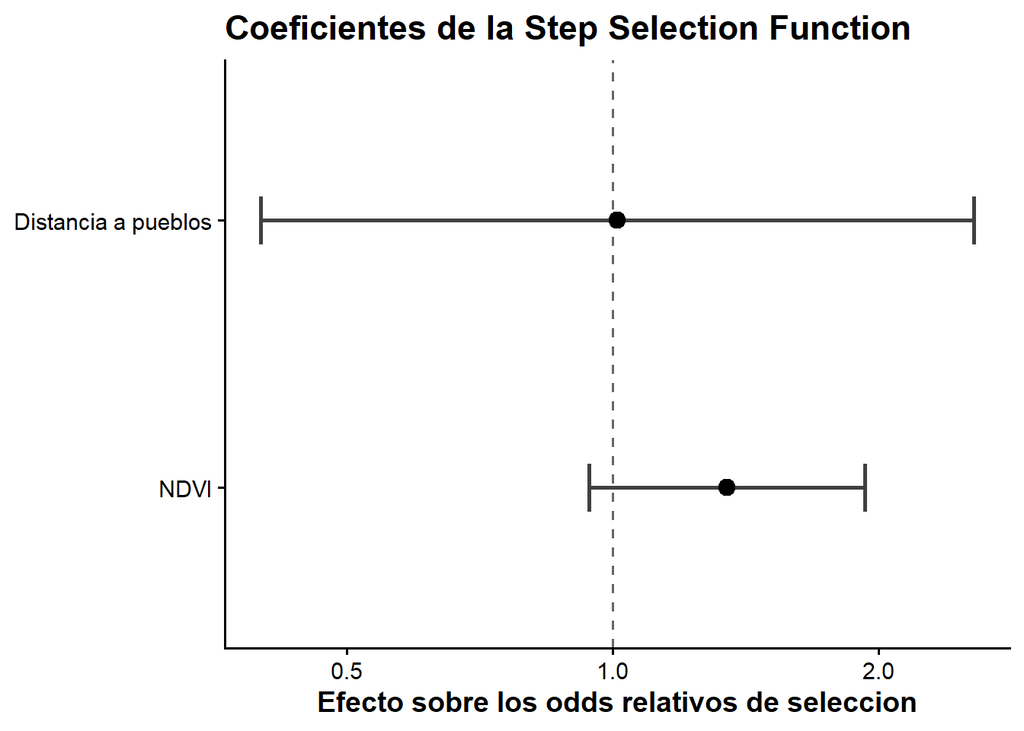

```r
ggplot(ssf_coef,
       aes(x = estimate,
           y = term)) +

  geom_vline(xintercept = 1,
             linetype = "dashed",
             linewidth = 0.7,
             color = "grey40") +

  geom_errorbarh(aes(xmin = conf.low,
                     xmax = conf.high),
                 height = 0.18,
                 linewidth = 0.9,
                 color = "grey25") +

  geom_point(size = 3.5,
             color = "black") +

  scale_x_log10() +

  labs(x = "Efecto sobre los odds relativos de seleccion",
       y = NULL,
       title = "Coeficientes de la Step Selection Function") +

  theme_classic(base_size = 14) +
  theme(
    plot.title = element_text(face = "bold"),
    plot.subtitle = element_text(size = 11),
    axis.title = element_text(face = "bold"),
    axis.text = element_text(color = "black")
  )
```

```r
m_issf <- survival::clogit(case_ ~ NDVI_s + dist_town_s +
                             sl_safe + log_sl + cos_ta +
                             strata(step_id_),
                           data = ssf_cov)
```

```r
predict_issf_curve <- function(model, newdata, refdata){

  beta <- coef(model)
  V <- vcov(model)

  # Nos quedamos sólo con las columnas usadas en el modelo
  vars <- names(beta)

  X <- as.matrix(newdata[, vars, drop = FALSE])
  X_ref <- as.matrix(refdata[, vars, drop = FALSE])

  # Diferencia respecto al punto de referencia
  X_diff <- sweep(X, 2, X_ref[1, ], "-")

  eta_diff <- as.numeric(X_diff %*% beta)
  se_diff <- sqrt(diag(X_diff %*% V %*% t(X_diff)))

  out <- newdata

  out$eta_rel <- eta_diff
  out$eta_lwr <- eta_diff - 1.96 * se_diff
  out$eta_upr <- eta_diff + 1.96 * se_diff

  out$selection_rel <- exp(out$eta_rel)
  out$selection_lwr <- exp(out$eta_lwr)
  out$selection_upr <- exp(out$eta_upr)

  out
}
```

```r
ref_issf <- data.frame(
  NDVI_s = 0,
  dist_town_s = 0,
  sl_safe = median(ssf_cov$sl_safe, na.rm = TRUE),
  log_sl = log(median(ssf_cov$sl_safe, na.rm = TRUE)),
  cos_ta = 1
)
```

```r
ndvi_seq <- seq(min(ssf_cov$NDVI, na.rm = TRUE),
                max(ssf_cov$NDVI, na.rm = TRUE),
                length.out = 200)

ndvi_mean <- mean(ssf_cov$NDVI, na.rm = TRUE)
ndvi_sd   <- sd(ssf_cov$NDVI, na.rm = TRUE)

pred_ndvi_issf <- data.frame(
  NDVI = ndvi_seq,
  NDVI_s = (ndvi_seq - ndvi_mean) / ndvi_sd,
  dist_town_s = 0,
  sl_safe = ref_issf$sl_safe,
  log_sl = ref_issf$log_sl,
  cos_ta = ref_issf$cos_ta
)

pred_ndvi_issf <- predict_issf_curve(
  model = m_issf,
  newdata = pred_ndvi_issf,
  refdata = ref_issf
)
```

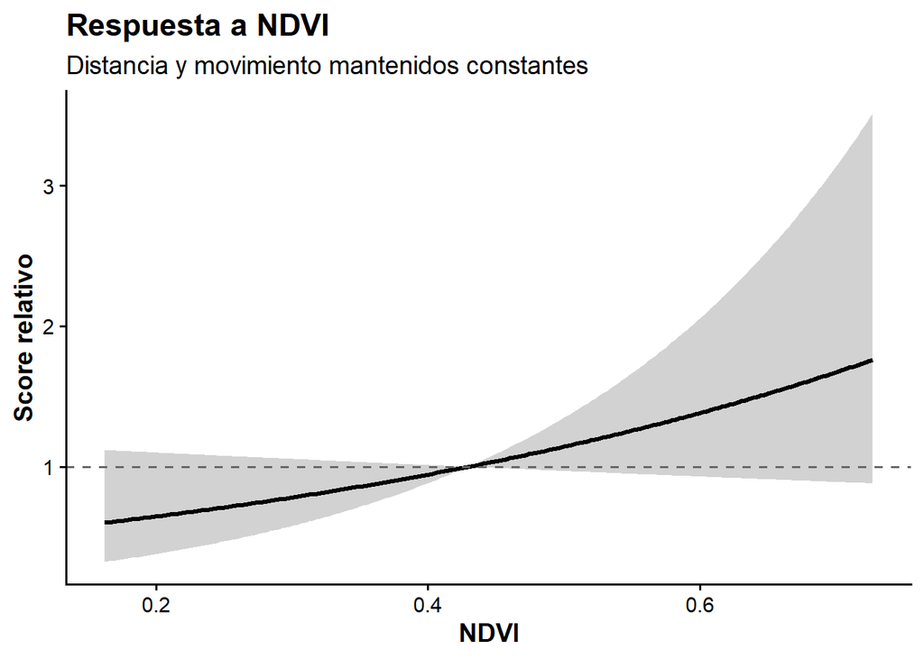

```r
p_ndvi_issf <- ggplot(pred_ndvi_issf,
                      aes(x = NDVI,
                          y = selection_rel)) +

  geom_ribbon(aes(ymin = selection_lwr,
                  ymax = selection_upr),
              alpha = 0.22) +

  geom_line(linewidth = 1.2) +

  geom_hline(yintercept = 1,
             linetype = "dashed",
             color = "grey40") +

  labs(x = "NDVI",
       y = "Score relativo",
       title = "Respuesta a NDVI",
       subtitle = "Distancia y movimiento mantenidos constantes") +

  theme_classic(base_size = 14) +
  theme(
    plot.title = element_text(face = "bold"),
    axis.title = element_text(face = "bold")
  )

p_ndvi_issf
```

```r
dist_seq <- seq(min(ssf_cov$dist_town, na.rm = TRUE),
                max(ssf_cov$dist_town, na.rm = TRUE),
                length.out = 200)

dist_mean <- mean(ssf_cov$dist_town, na.rm = TRUE)
dist_sd   <- sd(ssf_cov$dist_town, na.rm = TRUE)

pred_dist_issf <- data.frame(
  dist_town = dist_seq,
  NDVI_s = 0,
  dist_town_s = (dist_seq - dist_mean) / dist_sd,
  sl_safe = ref_issf$sl_safe,
  log_sl = ref_issf$log_sl,
  cos_ta = ref_issf$cos_ta
)

pred_dist_issf <- predict_issf_curve(
  model = m_issf,
  newdata = pred_dist_issf,
  refdata = ref_issf
)
```

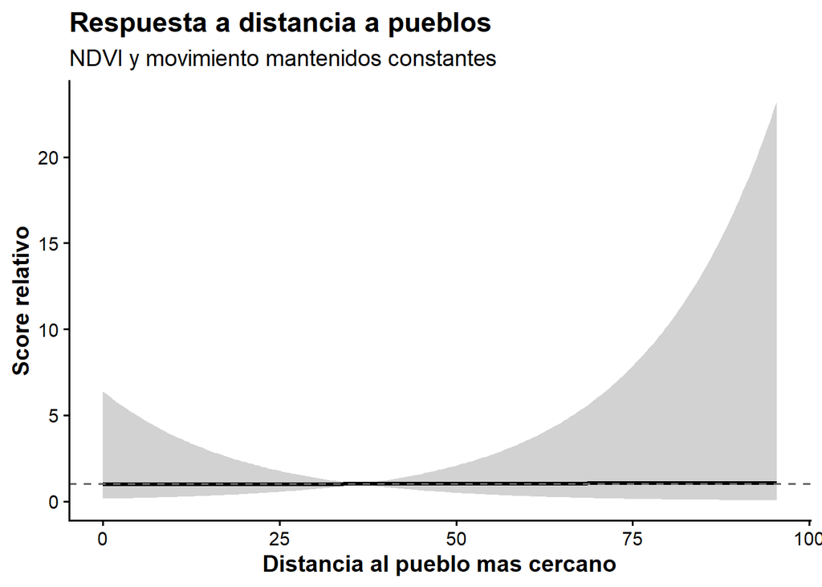

```r
p_dist_issf <- ggplot(pred_dist_issf,
                      aes(x = dist_town,
                          y = selection_rel)) +

  geom_ribbon(aes(ymin = selection_lwr,
                  ymax = selection_upr),
              alpha = 0.22) +

  geom_line(linewidth = 1.2) +

  geom_hline(yintercept = 1,
             linetype = "dashed",
             color = "grey40") +

  labs(x = "Distancia al pueblo mas cercano",
       y = "Score relativo",
       title = "Respuesta a distancia a pueblos",
       subtitle = "NDVI y movimiento mantenidos constantes") +

  theme_classic(base_size = 14) +
  theme(
    plot.title = element_text(face = "bold"),
    axis.title = element_text(face = "bold")
  )

p_dist_issf
```

```r
sl_seq <- seq(quantile(ssf_cov$sl_safe, 0.01, na.rm = TRUE),
              quantile(ssf_cov$sl_safe, 0.99, na.rm = TRUE),
              length.out = 200)

pred_sl_issf <- data.frame(
  step_length = sl_seq,
  NDVI_s = 0,
  dist_town_s = 0,
  sl_safe = sl_seq,
  log_sl = log(sl_seq),
  cos_ta = 1
)

pred_sl_issf <- predict_issf_curve(
  model = m_issf,
  newdata = pred_sl_issf,
  refdata = ref_issf
)
```

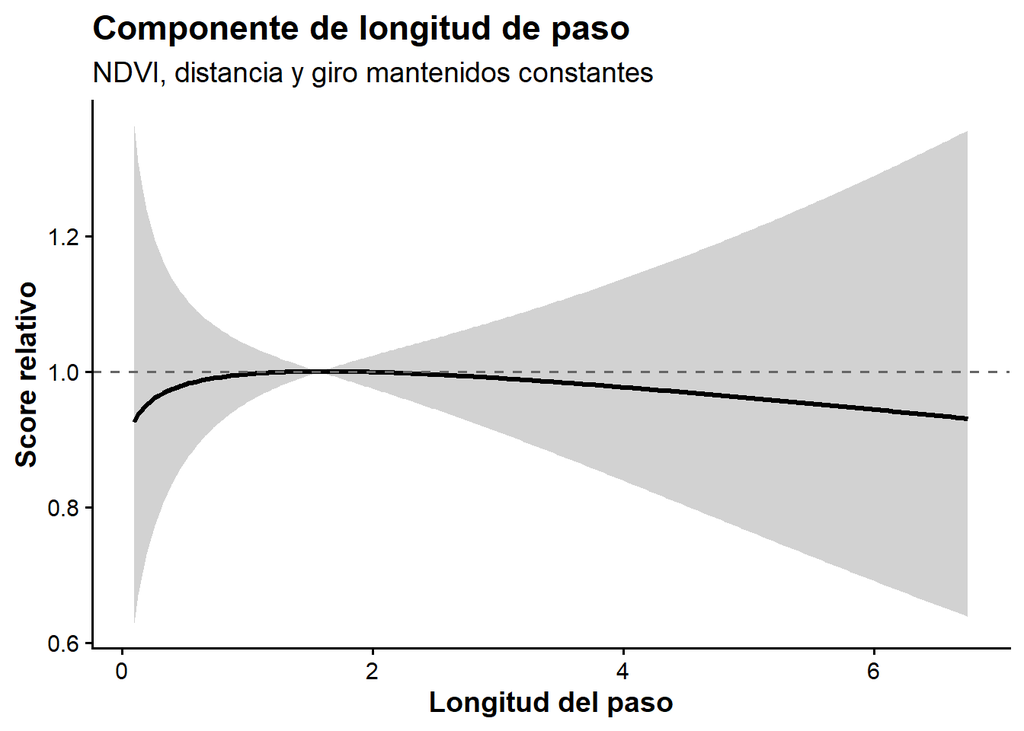

```r
p_sl_issf <- ggplot(pred_sl_issf,
                    aes(x = step_length,
                        y = selection_rel)) +

  geom_ribbon(aes(ymin = selection_lwr,
                  ymax = selection_upr),
              alpha = 0.22) +

  geom_line(linewidth = 1.2) +

  geom_hline(yintercept = 1,
             linetype = "dashed",
             color = "grey40") +

  labs(x = "Longitud del paso",
       y = "Score relativo",
       title = "Componente de longitud de paso",
       subtitle = "NDVI, distancia y giro mantenidos constantes") +

  theme_classic(base_size = 14) +
  theme(
    plot.title = element_text(face = "bold"),
    axis.title = element_text(face = "bold")
  )

p_sl_issf
```

```r
ta_seq <- seq(-pi, pi, length.out = 200)

pred_ta_issf <- data.frame(
  turn_angle = ta_seq,
  NDVI_s = 0,
  dist_town_s = 0,
  sl_safe = ref_issf$sl_safe,
  log_sl = ref_issf$log_sl,
  cos_ta = cos(ta_seq)
)

pred_ta_issf <- predict_issf_curve(
  model = m_issf,
  newdata = pred_ta_issf,
  refdata = ref_issf
)
```

```r
p_ta_issf <- ggplot(pred_ta_issf,
                    aes(x = turn_angle,
                        y = selection_rel)) +

  geom_ribbon(aes(ymin = selection_lwr,
                  ymax = selection_upr),
              alpha = 0.22) +

  geom_line(linewidth = 1.2) +

  geom_hline(yintercept = 1,
             linetype = "dashed",
             color = "grey40") +

  scale_x_continuous(
    breaks = c(-pi, -pi/2, 0, pi/2, pi),
    labels = c("-π", "-π/2", "0", "π/2", "π")
  ) +

  labs(x = "Angulo de giro",
       y = "Score relativo",
       title = "Persistencia direccional",
       subtitle = "Valores cercanos a 0 indican continuar hacia adelante") +

  theme_classic(base_size = 14) +
  theme(
    plot.title = element_text(face = "bold"),
    axis.title = element_text(face = "bold")
  )
```

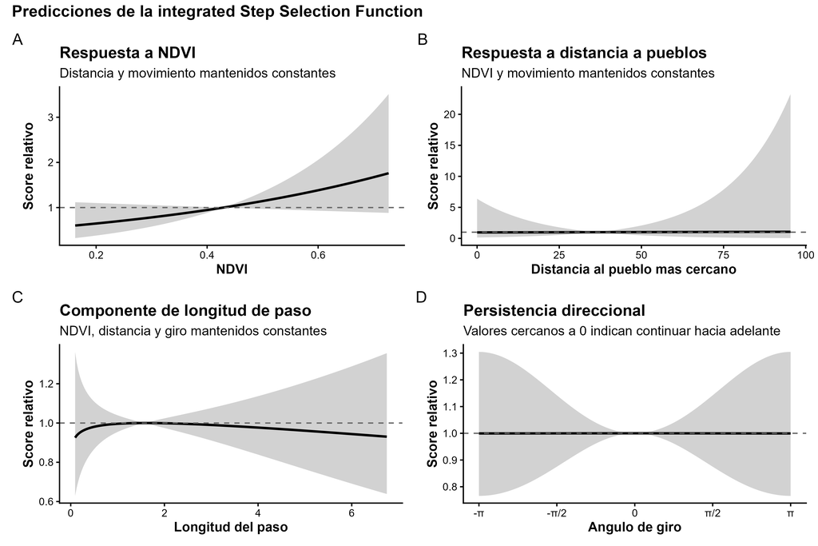

```r
library(patchwork)

p_issf_all <- (p_ndvi_issf | p_dist_issf) /
  (p_sl_issf | p_ta_issf) +
  plot_annotation(
    title = "Predicciones de la integrated Step Selection Function",
    tag_levels = "A",
    theme = theme(
      plot.title = element_text(face = "bold", size = 17),
      plot.subtitle = element_text(size = 12),
      plot.tag = element_text(face = "bold", size = 15)
    )
  )

ggsave("issf_predicciones.png",
       plot = p_issf_all,
       width = 12,
       height = 8,
       dpi = 300)

knitr::include_graphics("issf_predicciones.png")
```

Cada panel muestra cómo cambia el score relativo del modelo cuando variamos una sola variable y mantenemos las demás constantes. La línea punteada horizontal marca el valor 1, que representa el valor de referencia. Valores por encima de 1 indican mayor score relativo; valores por debajo de 1 indican menor score relativo.

La banda gris muestra la incertidumbre aproximada del modelo. Cuando la banda es muy ancha, la predicción es menos precisa y debe interpretarse con más cautela.

#### Predicción 1: respuesta a NDVI

El modelo sugiere que, manteniendo constantes la distancia a pueblos y las variables de movimiento, los pasos que terminan en sitios con mayor NDVI tienen mayor score relativo que los pasos que terminan en sitios con menor NDVI.

Esto es consistente con una tendencia de selección por sitios más verdes o productivos. Sin embargo, la banda gris se ensancha hacia valores altos de NDVI, lo que indica mayor incertidumbre en esa parte del gradiente.

#### Predicción 2: distancia a pueblos

La respuesta a la distancia a pueblos es prácticamente plana. Esto indica que, en este ejemplo, la distancia al pueblo más cercano no cambia de manera clara el score relativo de selección del paso.

En otras palabras, los pasos observados no parecen terminar sistemáticamente más cerca ni más lejos de los pueblos que los pasos alternativos.

#### PRedicción 4: Longitud de pasos

El componente de longitud de paso describe qué longitudes de movimiento son relativamente más compatibles con el patrón observado, manteniendo constantes las covariables ambientales y el ángulo de giro.

En este caso, la curva es casi plana y muestra una leve disminución para pasos más largos. Esto sugiere que, una vez incluidas las demás variables, no hay una preferencia fuerte por pasos más largos. Si acaso, los pasos muy largos tendrían un score relativo algo menor.

#### Predicción : Ángulos de Giro

La respuesta al ángulo de giro es prácticamente plana. Esto indica que el modelo no detecta una fuerte preferencia por continuar en la misma dirección ni por girar hacia atrás.

Si hubiera fuerte persistencia direccional, esperaríamos un score relativo más alto cerca de 0. Si hubiera tendencia a volver hacia atrás, esperaríamos valores más altos cerca de -π o π. En este caso, la curva no muestra un patrón claro.

#### En Conjunto

Las predicciones de la iSSF muestran dos componentes del modelo. Los paneles A y B corresponden a selección ambiental: NDVI y distancia a pueblos. Los paneles C y D corresponden al proceso de movimiento: longitud del paso y ángulo de giro.

El patrón más claro aparece en NDVI. La curva aumenta con el NDVI, lo que sugiere que los pasos observados tienden a terminar en sitios más verdes o productivos que los pasos alternativos. Sin embargo, la incertidumbre es considerable, por lo que esta tendencia debe interpretarse con cautela.

La distancia a pueblos no muestra una respuesta clara: la curva es casi plana y se mantiene cerca del valor de referencia. Esto indica que, en estos datos simulados, no hay evidencia de selección ni evitación de pueblos.

Los componentes de movimiento tampoco muestran patrones fuertes. La longitud del paso tiene una respuesta débil, con una leve disminución para pasos largos, y el ángulo de giro no muestra evidencia clara de persistencia direccional.

En conjunto, el modelo sugiere una tendencia de selección local por NDVI, pero poca evidencia de efectos fuertes de distancia a pueblos o de cambios marcados en el patrón de movimiento.